# STAT656_COVID_Project

# **1- Data Source Background, Discription and Loading**

### 1.2 Column Discription:

#### 1- case_month

**The earlier of month the Clinical Date (date related to the illness or specimen collection) or the Date Received by CDC**

#### 2- res_state

**State of residence**

#### 3- state_fips_code

**State FIPS code**

#### 4- res_county

**County of residence**

#### 5- county_fips_code

**County FIPS code**

#### 6- age_group

**Age group [0 - 17 years; 18 - 49 years; 50 - 64 years; 65 + years; Unknown; Missing; NA, if value suppressed for privacy protection.]**

#### 7- sex

**Sex [Female; Male; Other; Unknown; Missing; NA, if value suppressed for privacy protection.]**

#### 8- race

**Race [American Indian/Alaska Native; Asian; Black; Multiple/Other; Native Hawaiian/Other Pacific Islander; White; Unknown; Missing; NA, if value suppressed for privacy protection.]**

#### 9- ethnicity

**Ethnicity [Hispanic; Non-Hispanic; Unknown; Missing; NA, if value suppressed for privacy protection.]**

#### 10- case_positive_specimen_interval

**Weeks between earliest date and date of first positive specimen collection Number**

#### 11- case_onset_interval

**Weeks between earliest date and date of symptom onset. Number**

#### 12- process

**Under what process was the case first identified? [Clinical evaluation; Routine surveillance; Contact tracing of case patient; Multiple; Other; Unknown; Missing]**

#### 13- exposure_yn

**In the 14 days prior to illness onset, did the patient have any of the following known exposures: domestic travel, international travel, cruise ship or vessel travel as a passenger or crew member, workplace, airport/airplane, adult congregate living facility (nursing, assisted living, or long-term care facility), school/university/childcare center, correctional facility, community event/mass gathering, animal with confirmed or suspected COVID-19, other exposure, contact with a known COVID-19 case? [Yes, Unknown, Missing]**

#### 14- current_status

**What is the current status of this person? [Laboratory-confirmed case, Probable case]**

#### 15- symptom_status

**What is the symptom status of this person? [Asymptomatic, Symptomatic, Unknown, Missing]**

#### 16- hosp_yn

**Was the patient hospitalized? [Yes, No, Unknown, Missing]**

#### 17- icu_yn

**Was the patient admitted to an intensive care unit (ICU)? [Yes, No, Unknown, Missing]**

#### 18- death_yn

**Did the patient die as a result of this illness? [Yes; No; Unknown; Missing; NA, if value suppressed for privacy protection.]**

#### 19- underlying_conditions_yn

**Did the patient have one or more of the underlying medical conditions and risk behaviors: diabetes mellitus, hypertension, severe obesity (BMI>40), cardiovascular disease, chronic renal disease, chronic liver disease, chronic lung disease, other chronic diseases, immunosuppressive condition, autoimmune condition, current smoker, former smoker, substance abuse or misuse, disability, psychological/psychiatric, pregnancy, other. [Yes, No, blank]**

### 1.3 Loading Packages and Data:

```r
packs = c('dplyr','ggplot2', 'caret','corrplot', 'e1071','readr', 'pROC', 'lubridate')
invisible (lapply(packs,require,character.only=TRUE))
#rm(list=ls())# Just to clean up the memory again

# "dataSetPath" is the path variable to the directory on your PC where you place the dataset csv files

#Yako's Dataset Path
dataSetPath = '/home/yako/Desktop/TAMU_STAT/STAT656_Applied Analytics/STAT656FinalProject/Datasets'
#Laura's Dataset Path
#dataSetPath = '../'

dataSetName = 'COVID-19_Case_Surveillance_Public_Use_Data_with_Geography_Filterd.csv'
dataSet     = read_csv(file.path(dataSetPath,dataSetName))
head(dataSet, 3)
```

```
## # A tibble: 3 × 19
##   case_month res_s…¹ state…² res_c…³ count…⁴ age_g…⁵ sex   race  ethni…⁶ case_…⁷
##   <chr>      <chr>   <chr>   <chr>   <chr>   <chr>   <chr> <chr> <chr>     <dbl>
## 1 2020-11    KY      21      DAVIESS 21059   50 to … Male  White Non-Hi…      NA
## 2 2021-04    OH      39      WAYNE   39169   18 to … Fema… White Non-Hi…       0
## 3 2020-11    NC      37      SURRY   37171   65+ ye… Fema… White Non-Hi…       0
## # … with 9 more variables: case_onset_interval <dbl>, process <chr>,
## #   exposure_yn <chr>, current_status <chr>, symptom_status <chr>,
## #   hosp_yn <chr>, icu_yn <chr>, death_yn <chr>,
## #   underlying_conditions_yn <chr>, and abbreviated variable names ¹res_state,
## #   ²state_fips_code, ³res_county, ⁴county_fips_code, ⁵age_group, ⁶ethnicity,
## #   ⁷case_positive_specimen_interval
```

# **2- Exploratory Data Analysis**

Items that usually need to be checked:

- Data structures
- Checking for missing data
- Converting qualitative features to dummy variables
- Extreme observations
- Skewness/transformations
- Correlations

### 2.1 Checking The Overall Structure and Properties of The Dataset

```r
str(dataSet)
```

```
## spec_tbl_df [1,404,385 × 19] (S3: spec_tbl_df/tbl_df/tbl/data.frame)
##  $ case_month                     : chr [1:1404385] "2020-11" "2021-04" "2020-11" "2020-12" ...
##  $ res_state                      : chr [1:1404385] "KY" "OH" "NC" "OH" ...
##  $ state_fips_code                : chr [1:1404385] "21" "39" "37" "39" ...
##  $ res_county                     : chr [1:1404385] "DAVIESS" "WAYNE" "SURRY" "HANCOCK" ...
##  $ county_fips_code               : chr [1:1404385] "21059" "39169" "37171" "39063" ...
##  $ age_group                      : chr [1:1404385] "50 to 64 years" "18 to 49 years" "65+ years" "18 to 49 years" ...
##  $ sex                            : chr [1:1404385] "Male" "Female" "Female" "Female" ...
##  $ race                           : chr [1:1404385] "White" "White" "White" "White" ...
##  $ ethnicity                      : chr [1:1404385] "Non-Hispanic/Latino" "Non-Hispanic/Latino" "Non-Hispanic/Latino" "Non-Hispanic/Latino" ...
##  $ case_positive_specimen_interval: num [1:1404385] NA 0 0 NA 0 0 0 0 0 0 ...
##  $ case_onset_interval            : num [1:1404385] 0 0 0 0 0 0 NA NA 0 0 ...
##  $ process                        : chr [1:1404385] "Missing" "Contact tracing of case patient" "Missing" "Clinical evaluation" ...
##  $ exposure_yn                    : chr [1:1404385] "Yes" "Yes" "Missing" "Unknown" ...
##  $ current_status                 : chr [1:1404385] "Laboratory-confirmed case" "Probable Case" "Laboratory-confirmed case" "Probable Case" ...
##  $ symptom_status                 : chr [1:1404385] "Symptomatic" "Symptomatic" "Symptomatic" "Symptomatic" ...
##  $ hosp_yn                        : chr [1:1404385] "No" "No" "Yes" "No" ...
##  $ icu_yn                         : chr [1:1404385] "Missing" "No" "Unknown" "No" ...
##  $ death_yn                       : chr [1:1404385] "No" "No" "No" "No" ...
##  $ underlying_conditions_yn       : chr [1:1404385] "Yes" "Yes" "Yes" "Yes" ...
##  - attr(*, "spec")=
##   .. cols(
##   ..   case_month = col_character(),
##   ..   res_state = col_character(),
##   ..   state_fips_code = col_character(),
##   ..   res_county = col_character(),
##   ..   county_fips_code = col_character(),
##   ..   age_group = col_character(),
##   ..   sex = col_character(),
##   ..   race = col_character(),
##   ..   ethnicity = col_character(),
##   ..   case_positive_specimen_interval = col_double(),
##   ..   case_onset_interval = col_double(),
##   ..   process = col_character(),
##   ..   exposure_yn = col_character(),
##   ..   current_status = col_character(),
##   ..   symptom_status = col_character(),
##   ..   hosp_yn = col_character(),
##   ..   icu_yn = col_character(),
##   ..   death_yn = col_character(),
##   ..   underlying_conditions_yn = col_character()
##   .. )
##  - attr(*, "problems")=<externalptr>
```

### 2.2 Checking Number of Unique Values

```r
rbind(sapply(dataSet,function(x){ length(unique(x))}),
      sapply(dataSet,class))
```

```
##      case_month  res_state   state_fips_code res_county  county_fips_code
## [1,] "32"        "49"        "49"            "925"       "1317"
## [2,] "character" "character" "character"     "character" "character"
##      age_group   sex         race        ethnicity
## [1,] "5"         "6"         "9"         "5"
## [2,] "character" "character" "character" "character"
##      case_positive_specimen_interval case_onset_interval process
## [1,] "179"                           "89"                "11"
## [2,] "numeric"                       "numeric"           "character"
##      exposure_yn current_status symptom_status hosp_yn     icu_yn
## [1,] "3"         "2"            "4"            "2"         "4"
## [2,] "character" "character"    "character"    "character" "character"
##      death_yn    underlying_conditions_yn
## [1,] "2"         "2"
## [2,] "character" "character"
```

### 2.3 Checking For NA Values

```r
sapply(dataSet, function(x) sum(is.na(x)))
```

```
##                      case_month                       res_state
##                               0                              72
##                 state_fips_code                      res_county
##                              72                          124625
##                county_fips_code                       age_group
##                          124625                           22208
##                             sex                            race
##                           52195                          163249
##                       ethnicity case_positive_specimen_interval
##                          178634                          282665
##             case_onset_interval                         process
##                          219591                               0
##                     exposure_yn                  current_status
##                               0                               0
##                  symptom_status                         hosp_yn
##                               0                               0
##                          icu_yn                        death_yn
##                               0                               0
##        underlying_conditions_yn
##                               0
```

### 2.4 Droping Unwanted Columns

Reason for dropping:

- case_positive_specimen_interval, case_onset_interval, ethnicity: Too many NA values
- state_fips_code,res_county, county_fips_code, res_state : Geography related. Excluding from initial analysis

```r
dataSet <- dataSet %>% select (-c(case_positive_specimen_interval, case_onset_interval,
                                state_fips_code, ethnicity, res_county, county_fips_code, res_state))
```

### 2.5 Checking For NA Values Again

```r
sapply(dataSet, function(x) sum(is.na(x)))
```

```
##               case_month                age_group                      sex
##                        0                    22208                    52195
##                     race                  process              exposure_yn
##                   163249                        0                        0
##           current_status           symptom_status                  hosp_yn
##                        0                        0                        0
##                   icu_yn                 death_yn underlying_conditions_yn
##                        0                        0                        0
```

```r
#filtering out all these NAs
dataSet <- dataSet %>% filter(!is.na(age_group) & !is.na(sex) & !is.na(race))
sapply(dataSet, function(x) sum(is.na(x)))
```

```
##               case_month                age_group                      sex
##                        0                        0                        0
##                     race                  process              exposure_yn
##                        0                        0                        0
##           current_status           symptom_status                  hosp_yn
##                        0                        0                        0
##                   icu_yn                 death_yn underlying_conditions_yn
##                        0                        0                        0
```

### 2.6 Checking For Other Types of Missing Values

```r
# Extracting features that have "character" or "factor" type
catFteaures = names(dataSet[, sapply(dataSet, class) %in% c('character', 'factor')])

# Loop through selected categorical features and print frequency tables
for (colname in catFteaures){
  print(table(dataSet[colname]))
  print("------------------------------")
}
```

```
## case_month
## 2020-02 2020-03 2020-04 2020-05 2020-06 2020-07 2020-08 2020-09 2020-10 2020-11
##      29   21294   37674   25863   34876   51375   39718   42322   80682  125292
## 2020-12 2021-01 2021-02 2021-03 2021-04 2021-05 2021-06 2021-07 2021-08 2021-09
##  123246   99015   39031   30017   29464   15222    5595   24015   54972   49508
## 2021-10 2021-11 2021-12 2022-01 2022-02 2022-03 2022-04 2022-05 2022-06 2022-07
##   38172   43331   62712   69076   16069    3861    9032   22979   20922   17228
## 2022-08
##    8544
## [1] "------------------------------"
## age_group
##   0 - 17 years 18 to 49 years 50 to 64 years      65+ years
##          68922         552287         300134         319793
## [1] "------------------------------"
## sex
##  Female    Male Missing   Other Unknown
##  727087  512597     146       8    1298
## [1] "------------------------------"
## race
##          American Indian/Alaska Native                                  Asian
##                                   3575                                  16175
##                                  Black                                Missing
##                                 166391                                   6896
##                         Multiple/Other Native Hawaiian/Other Pacific Islander
##                                  10033                                   1847
##                                Unknown                                  White
##                                  44067                                 992152
## [1] "------------------------------"
## process
##                         Autopsy             Clinical evaluation
##                              24                          329377
## Contact tracing of case patient             Laboratory reported
##                           35254                           26720
##                         Missing                        Multiple
##                          704455                           55967
##                           Other               Provider reported
##                            6308                            5018
##    Routine physical examination            Routine surveillance
##                              38                           67764
##                         Unknown
```

[output cut: 15 more lines]

```
##      No     Yes
## 1067170  173966
## [1] "------------------------------"
## icu_yn
## Missing      No Unknown     Yes
##  471034  484691  258403   27008
## [1] "------------------------------"
## death_yn
##      No     Yes
## 1189458   51678
## [1] "------------------------------"
## underlying_conditions_yn
##      No     Yes
##   34815 1206321
## [1] "------------------------------"
```

```r
# Based on the tables above, some features having missing values encoded as ("Missing", "Other", "Unknown")
# we are going to remove those observations from the dataset
dataSet <- dataSet %>%
  filter(!(sex %in% c("Missing", "Other", "Unknown")) &
           !(race %in% c("Missing", "Other", "Unknown")) &
           !(process %in% c("Missing", "Other", "Unknown")) &
           !(symptom_status %in% c("Missing", "Other", "Unknown")) &
           !(icu_yn %in% c("Missing", "Other", "Unknown")))

# we also notice the feature "exposure_yn" only contains some "yes" values and the rest are all "Missing" or "Unknown" - therefore we decided to remove this feature too
dataSet <- dataSet %>% select (-c(exposure_yn))
```

```r
catFteaures = names(dataSet[, sapply(dataSet, class) %in% c('character', 'factor')])
for (colname in catFteaures){
  print(table(dataSet[colname]))
  print("------------------------------")
}
```

```
## case_month
## 2020-03 2020-04 2020-05 2020-06 2020-07 2020-08 2020-09 2020-10 2020-11 2020-12
##    3597    8245    7095   11208   14404   10324   10769   23939   33091   25597
## 2021-01 2021-02 2021-03 2021-04 2021-05 2021-06 2021-07 2021-08 2021-09 2021-10
##   21672    8534    7467    8884    4776    1523    5871    9373    7241    5775
## 2021-11 2021-12 2022-01 2022-02 2022-03 2022-04 2022-05 2022-06 2022-07 2022-08
##    5846    7391    6587    1551     740    2115    6048    5366    2986    1455
## [1] "------------------------------"
## age_group
##   0 - 17 years 18 to 49 years 50 to 64 years      65+ years
##          17819         123384          67128          61139
## [1] "------------------------------"
## sex
## Female   Male
## 149886 119584
## [1] "------------------------------"
## race
##          American Indian/Alaska Native                                  Asian
##                                    289                                   6639
##                                  Black                         Multiple/Other
##                                  33571                                   3056
## Native Hawaiian/Other Pacific Islander                                  White
##                                    968                                 224947
## [1] "------------------------------"
## process
##                         Autopsy             Clinical evaluation
##                               5                          151819
## Contact tracing of case patient             Laboratory reported
##                           21605                           11773
##                        Multiple               Provider reported
##                           40656                             486
##    Routine physical examination            Routine surveillance
##                              20                           43106
## [1] "------------------------------"
## current_status
## Laboratory-confirmed case             Probable Case
##                    235049                     34421
## [1] "------------------------------"
## symptom_status
## Asymptomatic  Symptomatic
##         9857       259613
## [1] "------------------------------"
## hosp_yn
##     No    Yes
## 228049  41421
## [1] "------------------------------"
## icu_yn
##     No    Yes
## 259310  10160
## [1] "------------------------------"
## death_yn
##     No    Yes
## 260972   8498
## [1] "------------------------------"
## underlying_conditions_yn
##     No    Yes
##  23689 245781
## [1] "------------------------------"
```

### 2.7 Creating conditional frequency plots and frequency tables

- Here we build a function to loop through the categorical features and plot frequency charts of their levels conditioned on the levels of our response variable

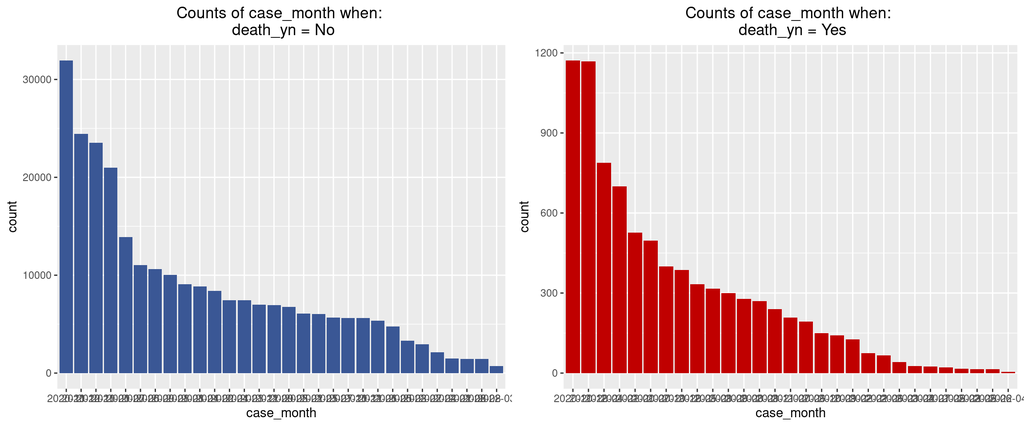

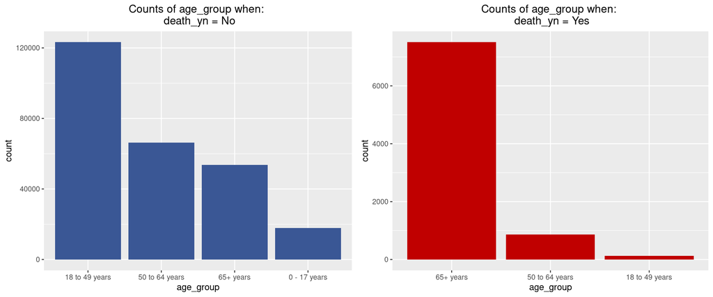

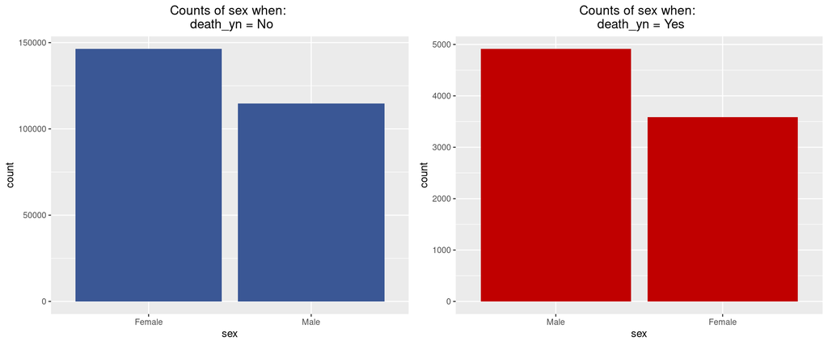

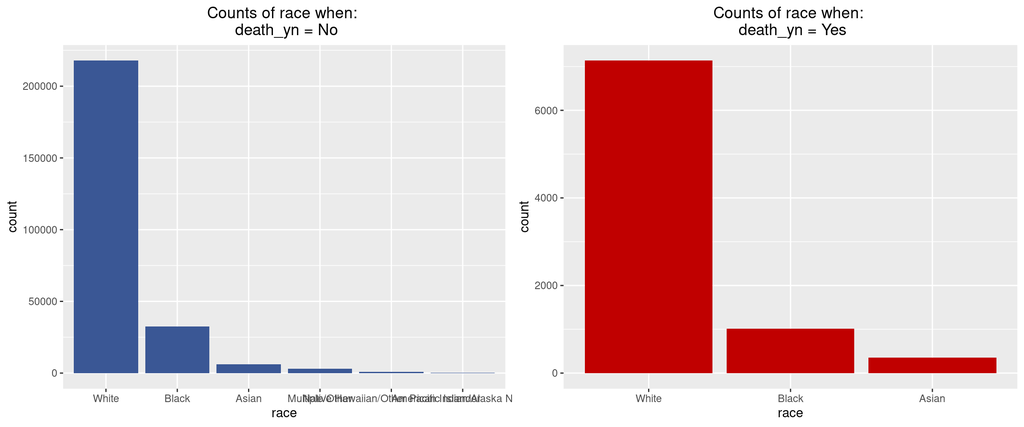

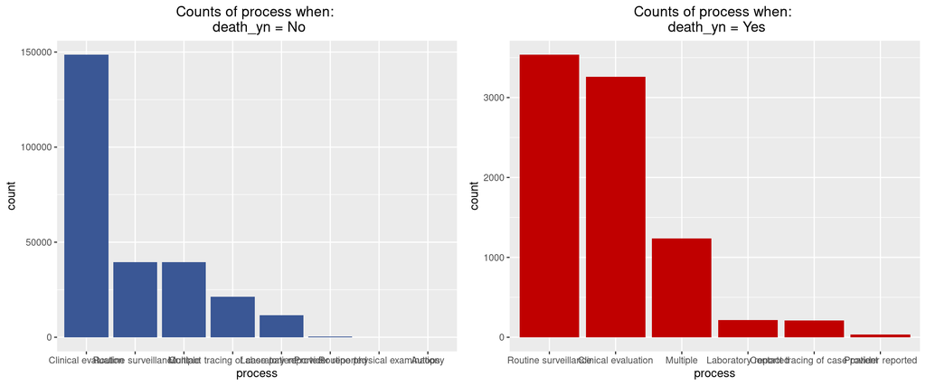

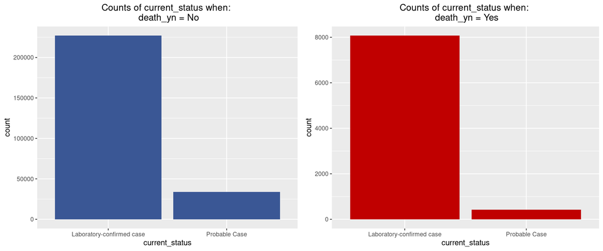

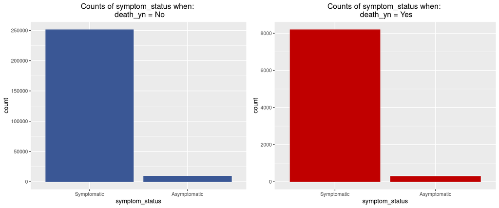

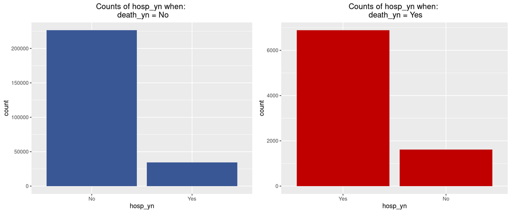

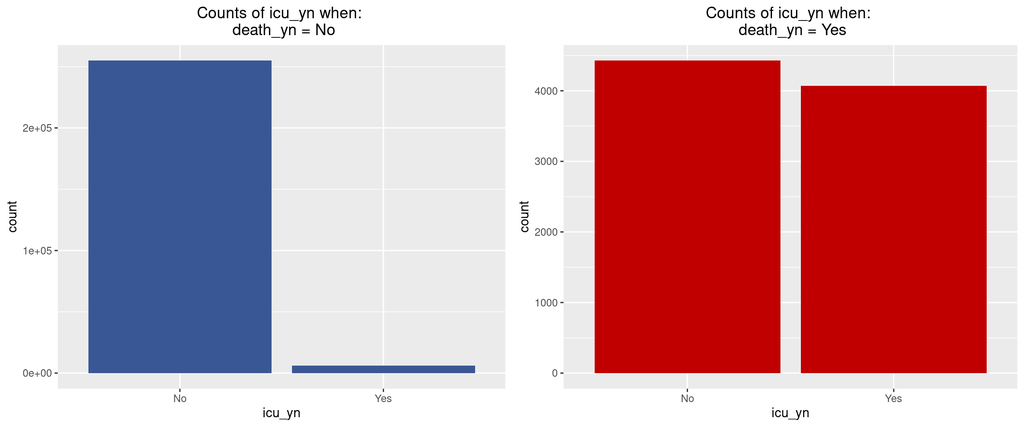

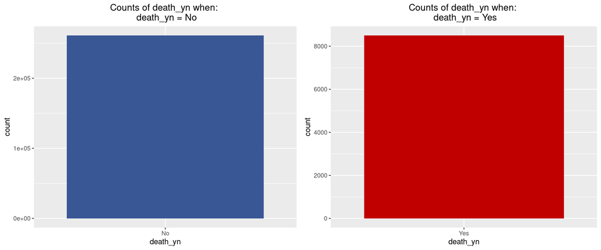

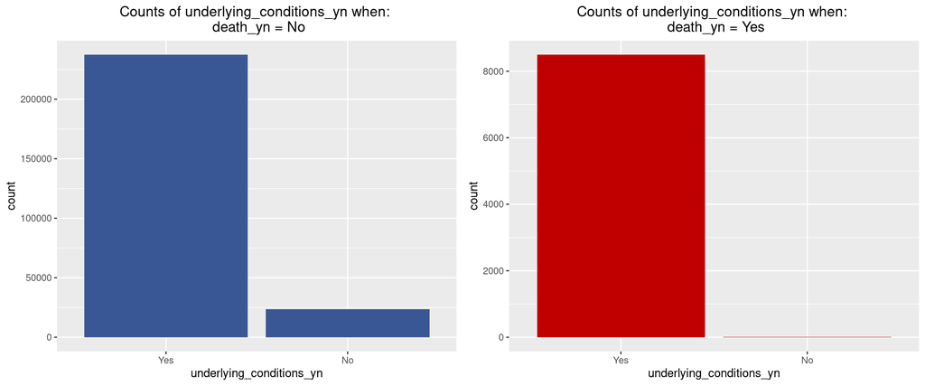

```r
require(gridExtra)
theme_update(plot.title = element_text(hjust = 0.5))

# Loop through selected categorical features and plot
for (colname in catFteaures) {

  plot1 = ggplot(filter(dataSet,death_yn == "No" ), aes(x=reorder(.data[[colname]], .data[[colname]], function(x)-length(x)))) + geom_bar(fill="#3A5795") +  labs(x=colname) + labs(title = paste("Counts of", colname, "when:", "\n", "death_yn" , "=", "No" ))

  plot2 = ggplot(filter(dataSet,death_yn == "Yes" ), aes(x=reorder(.data[[colname]], .data[[colname]], function(x)-length(x)))) + geom_bar(fill="#c00000") +  labs(x=colname) + labs(title = paste("Counts of", colname, "when:", "\n", "death_yn" , "=", "Yes" ))

  grid.arrange(plot1, plot2, ncol=2)
}
```

Note from Laura: This underlying_conditions_yn column might be problematic

# **3- Building Models**

### 2.1 Train/Test Data spliting:

```r
#partition data into train / test split
set.seed(13)
trainingDataIndex <- createDataPartition(dataSet$death_yn, p=.7, list=FALSE)
trainingData <- dataSet[trainingDataIndex,]
testingData <- dataSet[-trainingDataIndex,]

#split predictors and supervisor variable
Xtrain <- select(trainingData, -death_yn)
Xtest  <- select(testingData, -death_yn)
# ?? Note: do we need to convert X to factors as well like the example below from lectures?
#Xtrain = select(Xtrain, MONTH, OP_UNIQUE_CARRIER) %>% mutate_all(factor)
#Xtest = select(Xtest, MONTH, OP_UNIQUE_CARRIER) %>% mutate_all(factor)

Ytrain <- factor(select(trainingData, death_yn) %>% unlist())
Ytest  <- factor(select(testingData, death_yn) %>% unlist())
```

```r
#train dummy model and apply to predictors
#NOTE: this needs to be changed if we end up using some predictors that are not categorical
dummyModel <- dummyVars(~ ., data= Xtrain, fullRank = TRUE)

XtrainFull = predict(dummyModel, Xtrain)
XtestFull = predict(dummyModel, Xtest)

#We want to be explicit about what is the event and what is not, so we need to relevel
#NOTE: I'm not sure about this, but I think we DON'T want the event as the reference category. This may be incorrect
YtrainRelevel = relevel(Ytrain, ref = 'No')
YtestRelevel = relevel(Ytest, ref = 'No')
```

### 3.2 Applying Logistic Regression Model:

```r
#training logistic regression model
trControl = trainControl(method = 'none')
outLogistic = train(x = XtrainFull, y = YtrainRelevel,
                    method = 'glm', trControl = trControl)
YhatTestProbLR = predict(outLogistic, XtestFull, type = 'prob')
```

Let’s look at a calibration plot of our probabilities

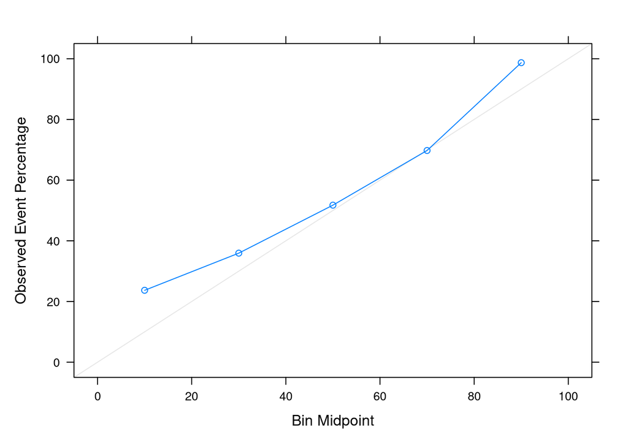

```r
calibProbs = calibration(YtestRelevel ~ YhatTestProbLR$No, cuts = 5)
xyplot(calibProbs)
```

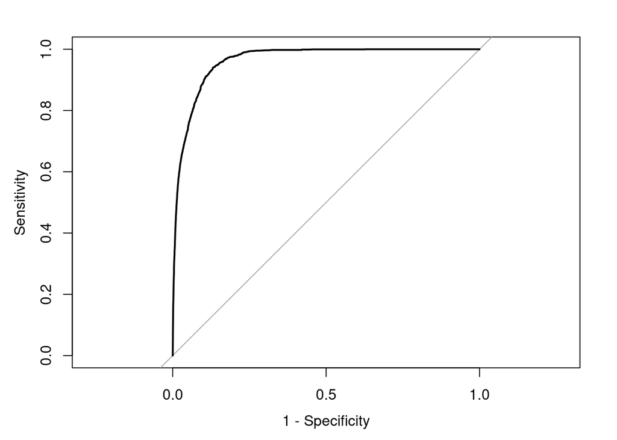

```r
#generating the roc curve
rocCurveLR = roc(Ytest, YhatTestProbLR$Yes)
#plot the roc
plot(rocCurveLR, legacy.axes=TRUE)
```

```r
rocCurveLR$auc
```

```
## Area under the curve: 0.9631
```

```r
#find threshold by setting based on sensitivity or specificity
thresholdsLR = rocCurveLR$thresholds
pt8 = max(which(rocCurveLR$sensitivities >= 0.80) )
thresholdLR = thresholdsLR[pt8]
specificityLR = rocCurveLR$specificities[pt8]
sensitivityLR = rocCurveLR$sensitivities[pt8]

YhatTestThreshLR = ifelse(YhatTestProbLR$Yes > thresholdLR, 'Yes', 'No') %>% as.factor

confusionMatrixOutLR = confusionMatrix(reference = YtestRelevel, data = YhatTestThreshLR, positive = "Yes")
confusionMatrixOutLR
```

```
## Confusion Matrix and Statistics
##
##           Reference
## Prediction    No   Yes
##        No  73194   509
##        Yes  5097  2040
##
##                Accuracy : 0.9307
##                  95% CI : (0.9289, 0.9324)
##     No Information Rate : 0.9685
##     P-Value [Acc > NIR] : 1
##
##                   Kappa : 0.393
##
##  Mcnemar's Test P-Value : <2e-16
##
##             Sensitivity : 0.80031
##             Specificity : 0.93490
##          Pos Pred Value : 0.28583
##          Neg Pred Value : 0.99309
##              Prevalence : 0.03153
##          Detection Rate : 0.02524
##    Detection Prevalence : 0.08829
##       Balanced Accuracy : 0.86761
##
##        'Positive' Class : Yes
##
```

### 3.3 Applying Logistic Elastic Net Model:

```r
set.seed(13)
K            = 10
trainControl = trainControl(method = "cv", number = K)
tuneGrid     = expand.grid('alpha'=c(0,.25,.5,.75,1),'lambda' = seq(00, .001, length.out = 30))

elasticOut = train(x = XtrainFull, y = YtrainRelevel,
                   method = "glmnet",
                   trControl = trainControl, tuneGrid = tuneGrid)
```

```r
#starting to look at the output from the model
#elasticOut$finalModel$beta[,1:6]

#best tune from the model
elasticOut$bestTune
```

```
##    alpha lambda
## 30     0  0.001
```

```r
#re-train the model using the parameters from the best tune
require(glmnet)
glmnetOut      = glmnet(x = as.matrix(XtrainFull), y = YtrainRelevel, s=elasticOut$bestTune$alpha,
                        family = 'binomial', standardize = FALSE)
probHatTestGlmnet   = predict(glmnetOut, XtestFull, s=elasticOut$bestTune$lambda, type='response')
YhatTestGlmnet = ifelse(probHatTestGlmnet > 0.035, 'Yes', 'No')
```

Let’s make a calibration plot of our probabilities:

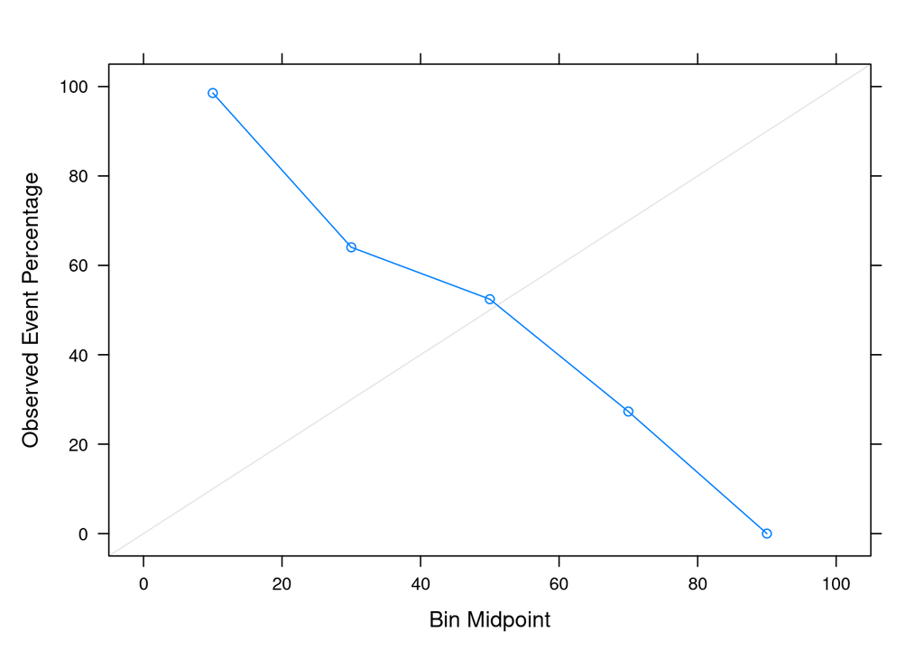

```r
calibProbsGLMnet = calibration(YtestRelevel ~ probHatTestGlmnet, cuts = 5)
xyplot(calibProbsGLMnet)
```

```r
#looking at the coefficients from the best tune
betaHatGlmnet = coef(glmnetOut, s=elasticOut$bestTune$lambda)
betaHatGlmnet
```

```
## 51 x 1 sparse Matrix of class "dgCMatrix"
##                                                     s1
## (Intercept)                                -5.60801243
## case_month2020-04                           0.30717070
## case_month2020-05                           .
## case_month2020-06                           .
## case_month2020-07                           .
## case_month2020-08                           .
## case_month2020-09                           .
## case_month2020-10                           .
## case_month2020-11                           .
## case_month2020-12                           0.01473699
## case_month2021-01                           .
## case_month2021-02                           .
## case_month2021-03                           .
## case_month2021-04                           .
## case_month2021-05                           .
## case_month2021-06                           .
## case_month2021-07                           .
## case_month2021-08                           .
## case_month2021-09                           .
## case_month2021-10                           .
## case_month2021-11                           .
## case_month2021-12                           .
## case_month2022-01                           .
## case_month2022-02                           .
## case_month2022-03                           .
## case_month2022-04                           .
## case_month2022-05                           .
## case_month2022-06                           .
## case_month2022-07                           .
## case_month2022-08                           .
## age_group18 to 49 years                    -0.69929894
## age_group50 to 64 years                     .
## age_group65+ years                          2.14784767
## sexMale                                     0.10089669
## raceAsian                                   .
## raceBlack                                   .
## raceMultiple/Other                          .
## raceNative Hawaiian/Other Pacific Islander  .
## raceWhite                                   .
## processClinical evaluation                 -0.33900126
## processContact tracing of case patient      .
## processLaboratory reported                  .
## processMultiple                             .
## processProvider reported                    .
## processRoutine physical examination         .
## processRoutine surveillance                 0.79140148
## current_statusProbable Case                 .
## symptom_statusSymptomatic                   .
## hosp_ynYes                                  1.75596165
## icu_ynYes                                   1.81083561
## underlying_conditions_ynYes                 .
```

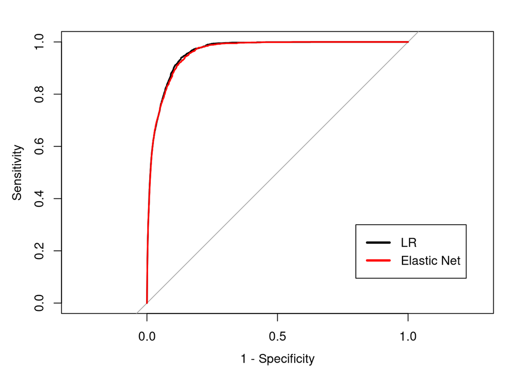

```r
#plot ROC curve and get AUC
probHatTestGlmnet = predict(elasticOut, XtestFull, s=elasticOut$bestTune$lambda, type = 'prob')
rocOutGlmnet = roc(response = YtestRelevel, probHatTestGlmnet$Yes)
plot(rocCurveLR, legacy.axes=TRUE)
plot(rocOutGlmnet, col = 'red', add = TRUE)
legend(0.2,0.3, legend=c("LR", "Elastic Net"), col=c("black", "red"), lty = 1, lwd = 3)
```

```r
# AUC Logistic Elastic Net
rocOutGlmnet$auc
```

```
## Area under the curve: 0.9614
```

```r
confusionMatrixOutGlmnet = confusionMatrix(reference = YtestRelevel, data = as.factor(YhatTestGlmnet), positive = "Yes")
confusionMatrixOutGlmnet
```

```
## Confusion Matrix and Statistics
##
##           Reference
## Prediction    No   Yes
##        No  69948   325
##        Yes  8343  2224
##
##                Accuracy : 0.8928
##                  95% CI : (0.8906, 0.8949)
##     No Information Rate : 0.9685
##     P-Value [Acc > NIR] : 1
##
##                   Kappa : 0.3038
##
##  Mcnemar's Test P-Value : <2e-16
##
##             Sensitivity : 0.87250
##             Specificity : 0.89344
##          Pos Pred Value : 0.21047
##          Neg Pred Value : 0.99538
##              Prevalence : 0.03153
##          Detection Rate : 0.02751
##    Detection Prevalence : 0.13071
##       Balanced Accuracy : 0.88297
##
##        'Positive' Class : Yes
##
```

### 3.4 Applying the LDA model

```r
trControl = trainControl(method = 'none')
outLDA = train(x = XtrainFull, y = YtrainRelevel,
                    method = 'lda', trControl = trControl)

YhatTestProbLDA = predict(outLDA, XtestFull, type = 'prob')
```

Let’s look at a calibration plot of our probabilities:

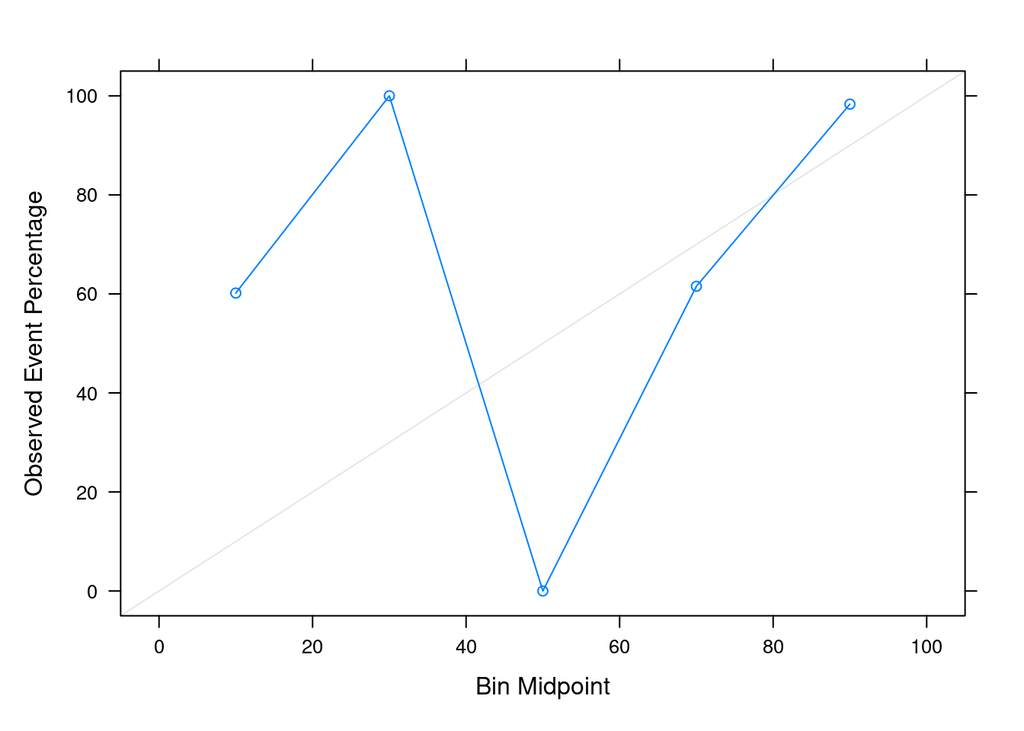

```r
#calibration plot for the LDA model
calibProbsLDA = calibration(YtestRelevel ~ YhatTestProbLDA$No, cuts = 5)
xyplot(calibProbsLDA)
```

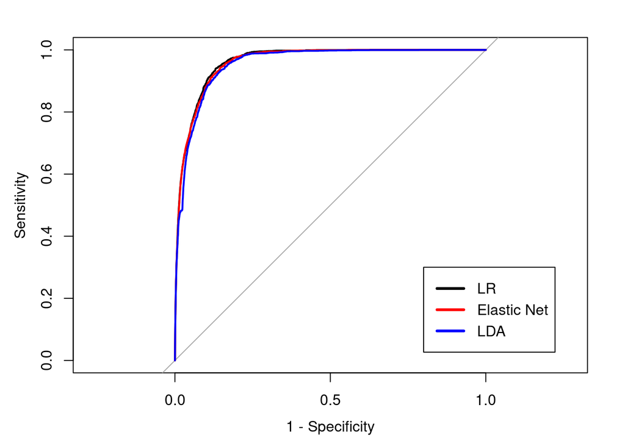

```r
#generating the roc curve
rocCurveLDA = roc(Ytest, YhatTestProbLDA$Yes)
#plot the roc
plot(rocCurveLR, legacy.axes=TRUE)
plot(rocOutGlmnet, col = 'red', add = TRUE)
plot(rocCurveLDA, col = 'blue', add = TRUE)
legend(0.2,0.3, legend=c("LR", "Elastic Net",  "LDA"), col=c("black", "red", "blue"), lty = 1, lwd = 3)
```

```r
rocCurveLDA$auc
```

```
## Area under the curve: 0.9562
```

```r
#find threshold for .8 sensitivity and generate confusion matrix
thresholdsLDA = rocCurveLDA$thresholds
pt8 = max(which(rocCurveLDA$sensitivities >= 0.80) )
thresholdLDA = thresholdsLDA[pt8]
specificityLDA = rocCurveLDA$specificities[pt8]
sensitivityLDA = rocCurveLDA$sensitivities[pt8]

YhatTestThreshLDA = ifelse(YhatTestProbLDA$Yes > thresholdLDA, 'Yes', 'No') %>% as.factor

confusionMatrixOutLDA = confusionMatrix(reference = YtestRelevel, data = YhatTestThreshLDA, positive = "Yes")
confusionMatrixOutLDA
```

```
## Confusion Matrix and Statistics
##
##           Reference
## Prediction    No   Yes
##        No  72378   507
##        Yes  5913  2042
##
##                Accuracy : 0.9206
##                  95% CI : (0.9187, 0.9224)
##     No Information Rate : 0.9685
##     P-Value [Acc > NIR] : 1
##
##                   Kappa : 0.3581
##
##  Mcnemar's Test P-Value : <2e-16
##
##             Sensitivity : 0.80110
##             Specificity : 0.92447
##          Pos Pred Value : 0.25669
##          Neg Pred Value : 0.99304
##              Prevalence : 0.03153
##          Detection Rate : 0.02526
##    Detection Prevalence : 0.09840
##       Balanced Accuracy : 0.86279
##
##        'Positive' Class : Yes
##
```

```r
knitr::knit_exit()
```